# Spam TXT Detection

Bin Kim

10/6/2020

```r
library(tidyverse)
library(ranger)
library(rpart)
library(janitor)
load("spam.rda")
wordmatrix_original = wordmatrix
```

# Use rpart to fit and prune (if necessary) a tree predicting spam/non-spam from the common word counts in the wordmatrix matrix. Report the accuracy with a confusion matrix. Plot the fitted tree (without all the labels) and comment on its shape.

```r
set.seed(763)
wordmatrix = as.data.frame(wordmatrix)

# cleaning column names
wordmatrix = janitor::clean_names(wordmatrix)
spam_df = cbind(is_spam=df$is_spam, wordmatrix)

# map for colnames(wordmatrix_original) -> colnames(spam_df)
spam_col_map = matrix(NA, nrow = 1, ncol = 630)
colnames(spam_col_map) = colnames(wordmatrix_original)
spam_col_map[1,] = colnames(wordmatrix)

spam_tree = rpart(factor(is_spam) ~ ., data=spam_df)
printcp(spam_tree)
```

```
##
## Classification tree:
## rpart(formula = factor(is_spam) ~ ., data = spam_df)
##
## Variables actually used in tree construction:
##  [1] w_awarded    w_call_2     w_claim      w_collection w_free_2
##  [6] w_free_3     w_me         w_mobile     w_po         w_reply_2
## [11] w_service    w_stop_2     w_text_2     w_txt_2      w_www
##
## Root node error: 747/5574 = 0.13402
##
## n= 5574
##
##          CP nsplit rel error  xerror     xstd
## 1  0.153949      0   1.00000 1.00000 0.034048
## 2  0.104418      1   0.84605 0.84605 0.031689
## 3  0.088353      2   0.74163 0.74163 0.029902
## 4  0.065596      3   0.65328 0.65328 0.028248
## 5  0.060241      4   0.58768 0.61178 0.027420
## 6  0.044177      5   0.52744 0.53681 0.025825
## 7  0.042838      6   0.48327 0.51539 0.025344
## 8  0.028112      7   0.44043 0.44043 0.023554
## 9  0.022758      8   0.41232 0.42838 0.023250
## 10 0.021419      9   0.38956 0.40964 0.022766
## 11 0.014279     10   0.36814 0.39893 0.022483
## 12 0.013387     13   0.32530 0.38822 0.022196
## 13 0.010000     15   0.29853 0.36011 0.021420
```

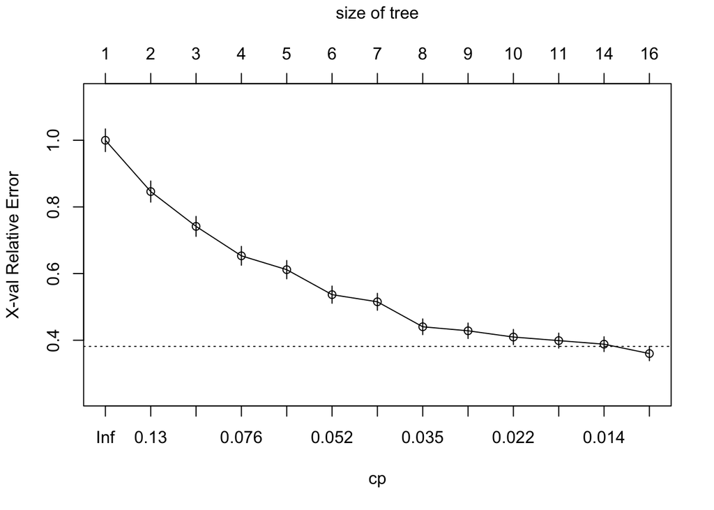

```r
plotcp(spam_tree)
```

Threshold = 0.36011 + 0.021420 = 0.38153. No prunning required as the second most complex tree's xerror (0.38822) is greater than the threshold.

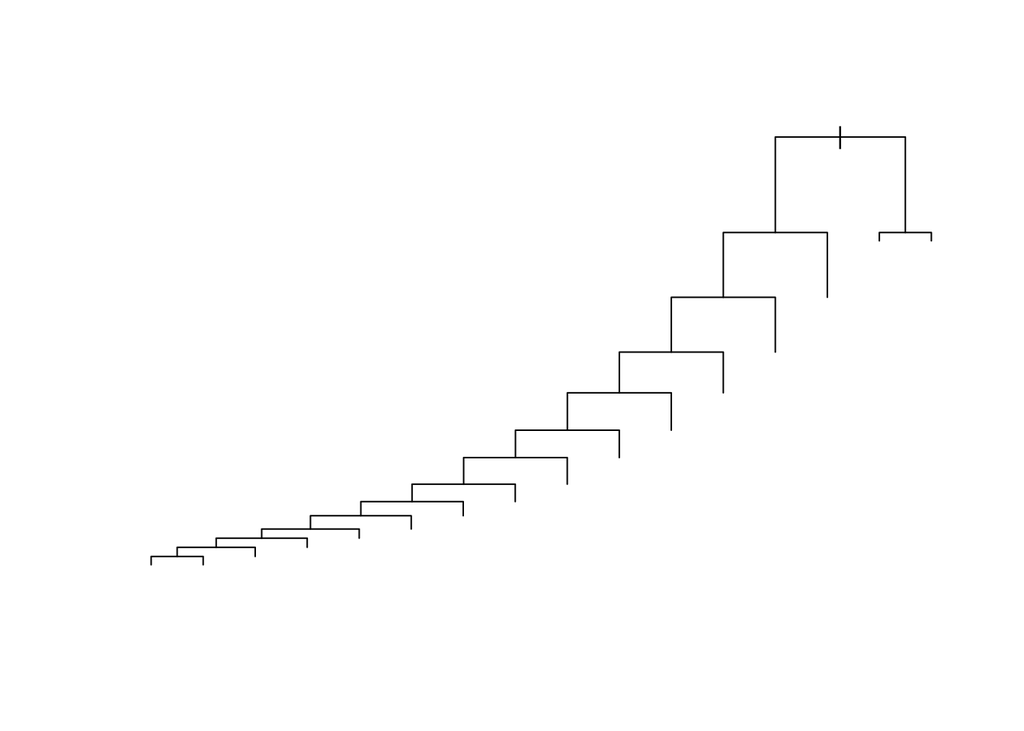

```r
plot(spam_tree)
```

```r
# confusion matrix
tree_cm = table(actual=spam_df$is_spam, predicted=predict(spam_tree, wordmatrix, type = "class"))
tree_cm
```

```
##        predicted
## actual  FALSE TRUE
##   FALSE  4785   42
##   TRUE    181  566
```

Interesting shape of the tree: all of the splits except one are done at the left side of the parent node. This probably means that the tree algorithm is exploiting certain set of words that occur frequently in the spam messages.

```r
spam_tree
```

```
## n= 5574
##
## node), split, n, loss, yval, (yprob)
##       * denotes terminal node
##
##     1) root 5574 747 FALSE (0.86598493 0.13401507)
##       2) w_call_2< 0.5 5417 611 FALSE (0.88720694 0.11279306)
##         4) w_www< 0.5 5335 531 FALSE (0.90046860 0.09953140)
##           8) w_claim< 0.5 5269 465 FALSE (0.91174796 0.08825204)
##            16) w_txt_2< 0.5 5212 412 FALSE (0.92095165 0.07904835)
##              32) w_mobile< 0.5 5141 354 FALSE (0.93114180 0.06885820)
##                64) w_free_3< 0.5 5106 320 FALSE (0.93732863 0.06267137)
##                 128) w_service< 0.5 5070 286 FALSE (0.94358974 0.05641026)
##                   256) w_po< 0.5 5049 265 FALSE (0.94751436 0.05248564)
##                     512) w_text_2< 0.5 5026 245 FALSE (0.95125348 0.04874652)
##                      1024) w_stop_2< 0.5 5008 228 FALSE (0.95447284 0.04552716)
##                        2048) w_reply_2< 0.5 4980 209 FALSE (0.95803213 0.04196787)
##                          4096) w_free_2< 0.5 4967 197 FALSE (0.96033823 0.03966177)
##                            8192) w_collection< 0.5 4956 186 FALSE (0.96246973 0.03753027)
##                             16384) w_awarded< 0.5 4946 176 FALSE (0.96441569 0.03558431) *
##                             16385) w_awarded>=0.5 10   0 TRUE (0.00000000 1.00000000) *
##                            8193) w_collection>=0.5 11   0 TRUE (0.00000000 1.00000000) *
##                          4097) w_free_2>=0.5 13   1 TRUE (0.07692308 0.92307692) *
##                        2049) w_reply_2>=0.5 28   9 TRUE (0.32142857 0.67857143) *
##                      1025) w_stop_2>=0.5 18   1 TRUE (0.05555556 0.94444444) *
##                     513) w_text_2>=0.5 23   3 TRUE (0.13043478 0.86956522) *
##                   257) w_po>=0.5 21   0 TRUE (0.00000000 1.00000000) *
##                 129) w_service>=0.5 36   2 TRUE (0.05555556 0.94444444) *
##                65) w_free_3>=0.5 35   1 TRUE (0.02857143 0.97142857) *
##              33) w_mobile>=0.5 71  13 TRUE (0.18309859 0.81690141) *
##            17) w_txt_2>=0.5 57   4 TRUE (0.07017544 0.92982456) *
##           9) w_claim>=0.5 66   0 TRUE (0.00000000 1.00000000) *
##         5) w_www>=0.5 82   2 TRUE (0.02439024 0.97560976) *
##       3) w_call_2>=0.5 157  21 TRUE (0.13375796 0.86624204)
##         6) w_me>=0.5 20   5 FALSE (0.75000000 0.25000000) *
##         7) w_me< 0.5 137   6 TRUE (0.04379562 0.95620438) *
```

The tree sequentially determines whether a given text message does NOT (w_ < 0.5) include words "Call" (w_call_2), "www", ..., "collection", "awarded", and if it does, with the exception of the first split word "Call", it immediately classifies the message as spam. If the text message contains words "Call" AND "me", then the tree classifies the text as Non-spam, and spam otherwise.

The strategy formed by the tree seems quite intuitive.

# For each common word in wordmatrix , compute the numbers y_i and n_i and that give, respectively, the number of occurrences in spam and non-spam messages. The overall evidence provided by having this word in a message can be approximated by e_i = log  ( y_i + 1 ) − log  ( n_i + 1 ). A `Naïve Bayes’ classifier sums up the e_i for every (common) word in the message to get an overall score for each message and then splits this at some threshold to get a classification. Construct a naïve Bayes classifier and choose the threshold so the proportion of spam predicted is the same as the proportion observed. Report the accuracy with a confusion matrix (It’s called naïve Bayes because it would be a Bayesian predictor if the words were all independently chosen, which they obviously won’t be)

```r
# get y_i, n_i
spam_yi_ni <- spam_df %>%
    group_by(is_spam) %>%
    summarise(across(everything(),sum)) %>%
    arrange(desc(is_spam))
spam_yi_ni
```

[output not shown]

```r
# Transpose spam_yi_ni to make common words the subject, then use mutate to get e_i
spam_e_i = spam_yi_ni %>%
    select(-is_spam) %>%
    rownames_to_column() %>%
    pivot_longer(-rowname, 'common_words', 'value') %>%
    pivot_wider(common_words, rowname) %>%
    rename("y_i" = "1", "n_i" = "2") %>%
    mutate(e_i = log(y_i + 1) - log(n_i + 1))

spam_e_i
```

```
## # A tibble: 630 x 4
##    common_words      y_i   n_i    e_i
##    <chr>           <int> <int>  <dbl>
##  1 w                2266 11605 -1.63
##  2 w_2                56   163 -1.06
##  3 w_3                 0    21 -3.09
##  4 w_4                 1    58 -3.38
##  5 w_5                 1    37 -2.94
##  6 w_6                98    13  1.96
##  7 w_amp               0    86 -4.47
##  8 w_lt_number_gt      0   276 -5.62
##  9 w_lt_decimal_gt     0    23 -3.18
## 10 w_7                18    11  0.460
## # … with 620 more rows
```

```r
nbc = NULL
for (txt_index in 1:nrow(wordmatrix_original)) { # for every text message
    nbc_i = 0 # txt_i's Naive Bayes Classifier
    txt_words = df[txt_index,3]
    for (word in txt_words[[1]]){ # for word in txt's word list
        word_col = paste("w_",word,sep="")
        if (word_col %in% colnames(wordmatrix_original)){ # if the word is a common word
            clean_word = spam_col_map[1, word_col] # using word map created in Q1
            word_value <- spam_e_i %>% #
                filter(common_words == clean_word) %>%
                select(e_i)
            nbc_i = nbc_i + as.numeric(word_value) # increment nbc_i by word's e_i value
        }
    }
    nbc = c(nbc, nbc_i)
}
```

```r
final = bind_cols(df, nbc=nbc)
threshold = -6.65
nbc_cm = table(actual=final$is_spam, predictions=final$nbc > -.895)

cat("Observed Spam Proportion:", mean(df$is_spam), "\n")
## Observed Spam Proportion: 0.1340151
cat("Naive Bayes Classifier Prediction Proportion:", mean(final$nbc > threshold), "\n", "\n")
## Naive Bayes Classifier Prediction Proportion: 0.1340151
##

nbc_cm
##        predictions
## actual  FALSE TRUE
##   FALSE  4784   43
##   TRUE    480  267
cat("Naive Bays Classifier Accuracy:", sum(nbc_cm[c(1,4)]) / sum(nbc_cm[c(1,2,3,4)]), "\n")
## Naive Bays Classifier Accuracy: 0.9061715
cat("Tree Classifier Accuracy:", sum(tree_cm[c(1,4)]) / sum(tree_cm[c(1,2,3,4)]), "\n")
## Tree Classifier Accuracy: 0.9599928
```

It wasn't hard to guestimate the threshold by trial and error.

# Q3

## Why is spam/non-spam accuracy likely to be higher with this dataset than in real life?

Because the dataset is not a random sample of one certain txt population. There's no evidence that the spam-to-ham ratio of the dataset is representative of the real world ratio. It seems unlikely that the real world spam message percentage is as high as 13% like it is in the dataset. Training on an inflated dataset will yield inflated accuracy because the algorithm has more false ground to be certain on.

The dataset designer gathered spam and non-spam txts from differenet sources and artificially glued them together, and this allows the algorithm to exploit the populations' characteristics. For example, all of the UK's txt messages are spam and all of the Singaporean txt messages are not. The algorithm may be able to exploit the cultural-linguistical differences between the two populations and use that to predict spam messages. However, in real life datasets, cultural-linguistical differences would not be as diverse because you'd usually be analysing samples from one population/country only.

## What can you say about the generalisability of the classifier to particular populations of text users?

In theory, heterogeneous data should make these classifiers less effective for a particular population because the dataset does not properly represent any of the population as the data is drawn from many sources. However, the tree may prove to be somewhat useful for because the construction of the tree seem very intuitive to reasonably classify any english text message (as discussed in Q1), and its 96% accuracy is very good for this dataset. The Naive Bayes classifier is still pretty good with 91% accuracy for this dataset, however, the obvious violation of Naive Bayes classifier's independence assumption degrades the validity of this classifier therefore also its genralisability, and its lower accuracy than tree classifier could also partially be attributed to it.